# Does your university faculty influence your gaming habits?

Project 2

510269285 520617829 520474923 520443620 510014478

University of Sydney | 23 Sep 2022

# 1 Executive Summary

# 2 Full Report

## 2.1 Initial Data Analysis (IDA)

```r
survey = read.csv("/Users/nabzulkapeli/Desktop/skewl/DATA1001/P2/gaming.csv")

head(survey, 5)
```

```
  Are.you.a.student.or.staff.at.the.University. Age Gender     Faculty
1                                       Student  18  Woman     Science
2                                       Student  19  Woman     Science
3                                       Student  23    Man Engineering
4                                       Student  19    Man     Science
5                                       Student  21    Man    Business
  Hours_On_Campus Employment_Type Hours_A_Week_Playing_Video_Game
1               0          Casual                               0
2               9          Casual                               4
3              40      Unemployed                               7
4              13       Full time                              20
5              20          Casual                               2
  Days_Played_Games_Last_Week Weeks_Last_Month_Played_Videogames
1                           3                  1 week in a month
2                           4                 2 weeks in a month
```

[output cut: 33 more lines]

```r
tail(survey, 5)
```

```
   Are.you.a.student.or.staff.at.the.University. Age            Gender
27                                       Student  20             Woman
28                                       Student  20             Woman
29                                       Student  19               Man
30                                       Student  19 Prefer not to say
31                                       Student  22               Man
                             Faculty Hours_On_Campus Employment_Type
27                           Science              12      Unemployed
28 Architecture, Design and Planning               5      Unemployed
29                           Science              28      Unemployed
30                       Engineering              14      Unemployed
31               Medicine and Health              32          Casual
   Hours_A_Week_Playing_Video_Game Days_Played_Games_Last_Week
27                               2                           1
28                               2                           2
```

[output cut: 33 more lines]

```r
str(survey)
```

```
'data.frame':   31 obs. of  19 variables:
 $ Are.you.a.student.or.staff.at.the.University.     : chr  "Student" "Student" "Student" "Student" ...
 $ Age                                               : int  18 19 23 19 21 20 19 20 20 18 ...
 $ Gender                                            : chr  "Woman" "Woman" "Man" "Man" ...
 $ Faculty                                           : chr  "Science" "Science" "Engineering" "Science" ...
 $ Hours_On_Campus                                   : int  0 9 40 13 20 10 11 30 14 42 ...
 $ Employment_Type                                   : chr  "Casual" "Casual" "Unemployed" "Full time" ...
 $ Hours_A_Week_Playing_Video_Game                   : int  0 4 7 20 2 0 10 10 4 5 ...
 $ Days_Played_Games_Last_Week                       : int  3 4 7 7 1 0 4 4 4 0 ...
 $ Weeks_Last_Month_Played_Videogames                : chr  "1 week in a month" "2 weeks in a month" "4 weeks in a month" "4 weeks in a month" ...
 $ Favourite_Game_Genre                              : chr  "Puzzle" "RPG" "RPG" "FPS" ...
 $ Most_Frequent_Platform_Played_Games               : chr  "Mobile (Phone, Tablet)" "Mobile (Phone, Tablet)" "Mobile (Phone, Tablet)" "Computer (PC, Mac)" ...
 $ Days_Per_Week_Exercise                            : int  2 0 0 2 5 4 2 5 5 2 ...
 $ Sleeping_Time                                     : chr  "11:00:00 PM" "2:00:00 AM" "1:00:00 AM" "3:00:00 AM" ...
 $ Hours_Of_Sleep                                    : int  6 5 6 6 7 7 5 7 4 6 ...
 $ Average_Mobile_Screen_Time_per_week_in_minutes    : num  5 NA 420 700 240 ...
 $ Favourite_Video_Game                              : chr  "Minecraft" "The Last of Us" "Genshin Impact" "Valorant" ...
 $ Approximate_Money_Spent_On_Games_In_Lifetime_.AUD.: int  50 50 0 50 0 NA 6000 1000 50 0 ...
 $ Personality_Type                                  : chr  "Ambivert" "Extrovert" "Extrovert" "Introvert" ...
 $ Wear_Glasses                                      : chr  "No" "No" "Yes" "No" ...
```

### 2.1.1 Summary

#### 2.1.1.1 Source:

- The data was obtained from a [Google Forms survey](https://forms.gle/D2vdH5DHTrhjD3uM9) which was active from 08/09/2022 to 16/09/2022.

#### 2.1.1.3 Limitations:

- This is a sample survey as only 31 responses were recorded. Not enough data was collected.
- There is not an equal amount of participants distributed across each faculty, so it would be difficult to pinpoint any differences with accuracy.
- The survey did not ask for the year or semester the participant is currently studying in.
- Due to selection bias, only 1 member of staff participated in the survey:

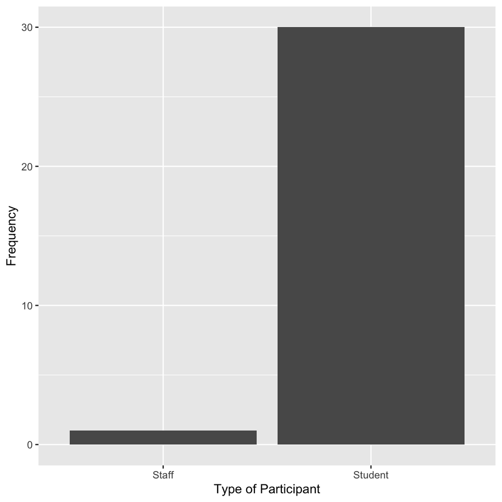

```r
ggplot(survey, aes(x = Are.you.a.student.or.staff.at.the.University.)) +
  geom_bar() +
  xlab("Type of Participant") +
  ylab("Frequency")
```

- **Possible bias and confounders:**
  - **Consent bias:** participants were able to choose to take part in the study.
  - **Selection bias:** the survey was spread via social media and ED, thus the participants might consist of like-minded individuals of similar ages and similar preferences.
  - **Observational studies:** cannot determine causation between investigative variables, only correlation.

### 2.1.2 Assumptions:

- It was assumed that participants were ongoing members of staff or students in university.

### 2.1.3 Data Cleaning:

- **Time of sleep:** The data is formatted as AM and PM time in the survey. Although the ability to convert time to an integer or float is possible, R/Studio might see 24 (12PM), as quite far from 1 (1AM) because of how integers are ordered. Hence it was set as an ordered category manually in R.
- **Qualitative Variables:** Results for qualitative variables were adjusted so that same responses (e.g. RPG. and RPG) were streamlined so producing graphs was much easier.

## 2.2 Research Questions

The main research theme for this project was to investigate the relationship between an **individual’s faculty, gaming habits, and sleep.**. To do so, we devised several research questions and produced corresponding graphs in order to determine if the variables had any relationship with each other.

### 2.2.1 1. Does the time spent on campus due to your faculty affect the amount of time you play games in a week?

- We can generate a scatter plot for the two quantitative variables:

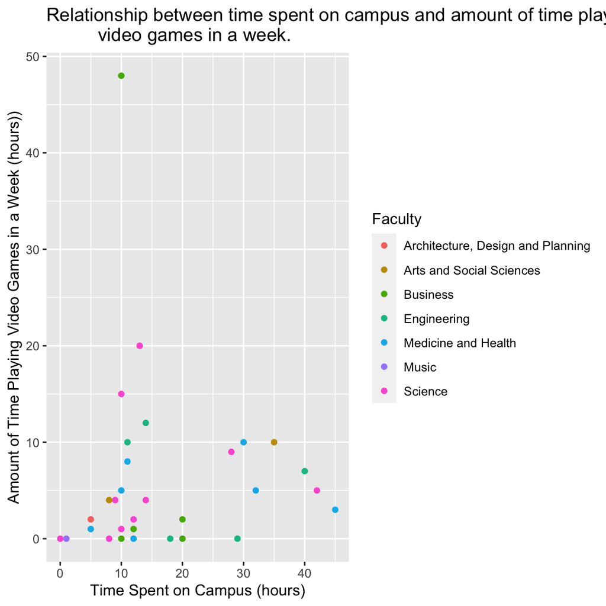

```r
ggplot(survey, aes(x = Hours_On_Campus, y = Hours_A_Week_Playing_Video_Game)) +
  geom_point(aes(colour = Faculty)) +
  ggtitle("Relationship between time spent on campus and amount of time playing
          video games in a week.") +
  xlab("Time Spent on Campus (hours)") +
  ylab("Amount of Time Playing Video Games in a Week (hours))")
```

- We can also calculate the correlation coefficient of the two variables:

```r
cor(survey$Hours_On_Campus, survey$Hours_A_Week_Playing_Video_Game)
```

```
[1] 0.01191024
```

- The correlation coefficient of the 2 variables is very low. We can attempt to remove the outlier and calculate the new correlation coefficient:

```r
survey_del =  survey[-22,]
cor(survey_del$Hours_On_Campus, survey_del$Hours_A_Week_Playing_Video_Game)
```

```
[1] 0.1864928
```

- The correlation is still a very weak positive, albeit higher than with the outlier. We can attempt to fit a linear model to the data, and produce a residual graph:

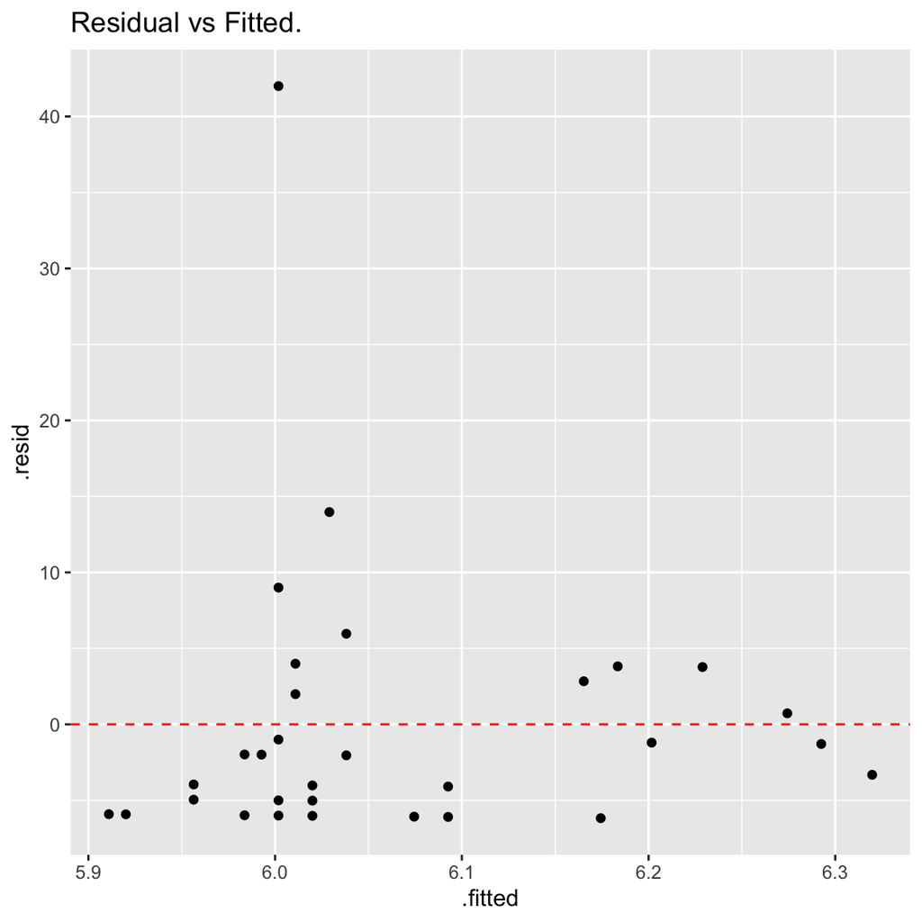

```r
fit = lm(survey$Hours_A_Week_Playing_Video_Game~ survey$Hours_On_Campus, data = survey)
ggplot(fit, aes(x = .fitted, y = .resid)) +
  geom_point() +
  geom_hline(yintercept = 0, linetype = "dashed", colour = "red") +
  ggtitle("Residual vs Fitted.")
```

- As can be seen above, the residual plot’s y-axis is unbalanced and the data is not clustered in the middle of the plot, or distributed evenly. This is not a good residual plot, and suggests our model can be improved much more.
- We can now produce 2 scatter plots (one with and one without the outlier) to include linear regression:

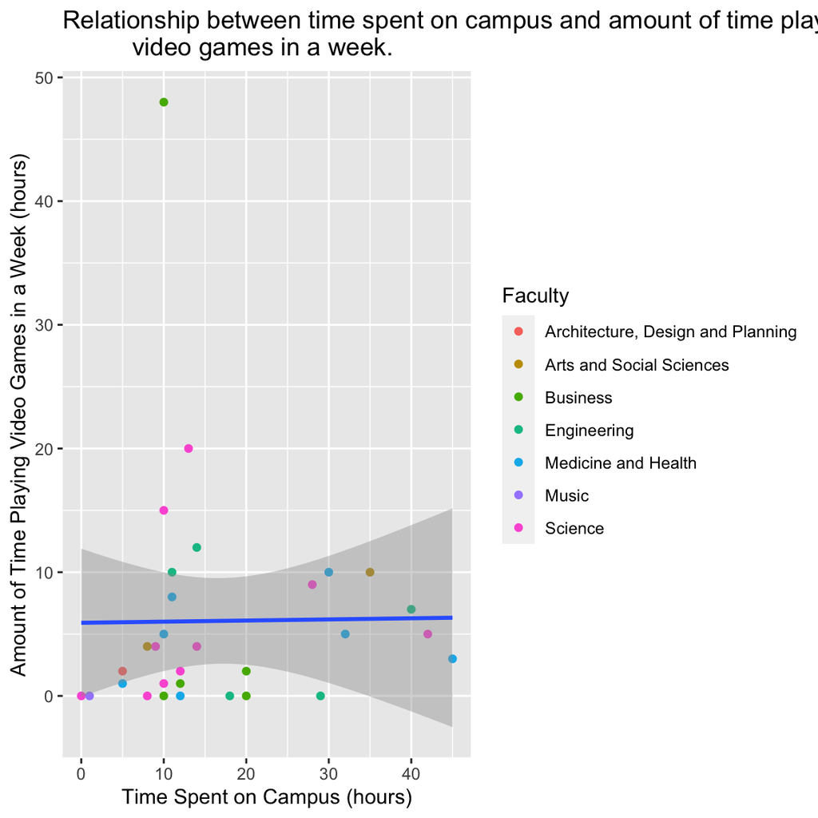

```r
ggplot(survey, aes(x = Hours_On_Campus , y = Hours_A_Week_Playing_Video_Game))+
  geom_point(aes(colour = Faculty)) +
  geom_smooth(method = "lm") +
  ggtitle("Relationship between time spent on campus and amount of time playing
          video games in a week.") +
  xlab("Time Spent on Campus (hours)") +
  ylab("Amount of Time Playing Video Games in a Week (hours)")
```

**Figure 1.** Scatter plot demonstrating relationship between on campus hours and gaming hours. The blue line represents the line of best fit for the data.

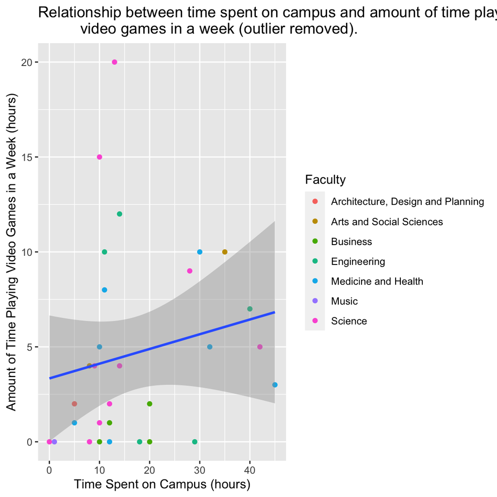

```r
ggplot(survey_del, aes(x = Hours_On_Campus , y = Hours_A_Week_Playing_Video_Game))+
  geom_point(aes(colour = Faculty)) +
  geom_smooth(method = "lm") +
  ggtitle("Relationship between time spent on campus and amount of time playing
          video games in a week (outlier removed).") +
  xlab("Time Spent on Campus (hours)") +
  ylab("Amount of Time Playing Video Games in a Week (hours)")
```

**Figure 2.** Scatter plot demonstrating relationship between on campus hours and gaming hours but omits an extreme outlier. The blue line represents the line of best fit for the data.

### 2.2.2 2. Does your university faculty affect your gaming habits?

- To investigate this research question, we produced graphs to determine a trend for faculty against the number of weeks video games are played in a month, and faculty against the number of hours video games were played in the last week.

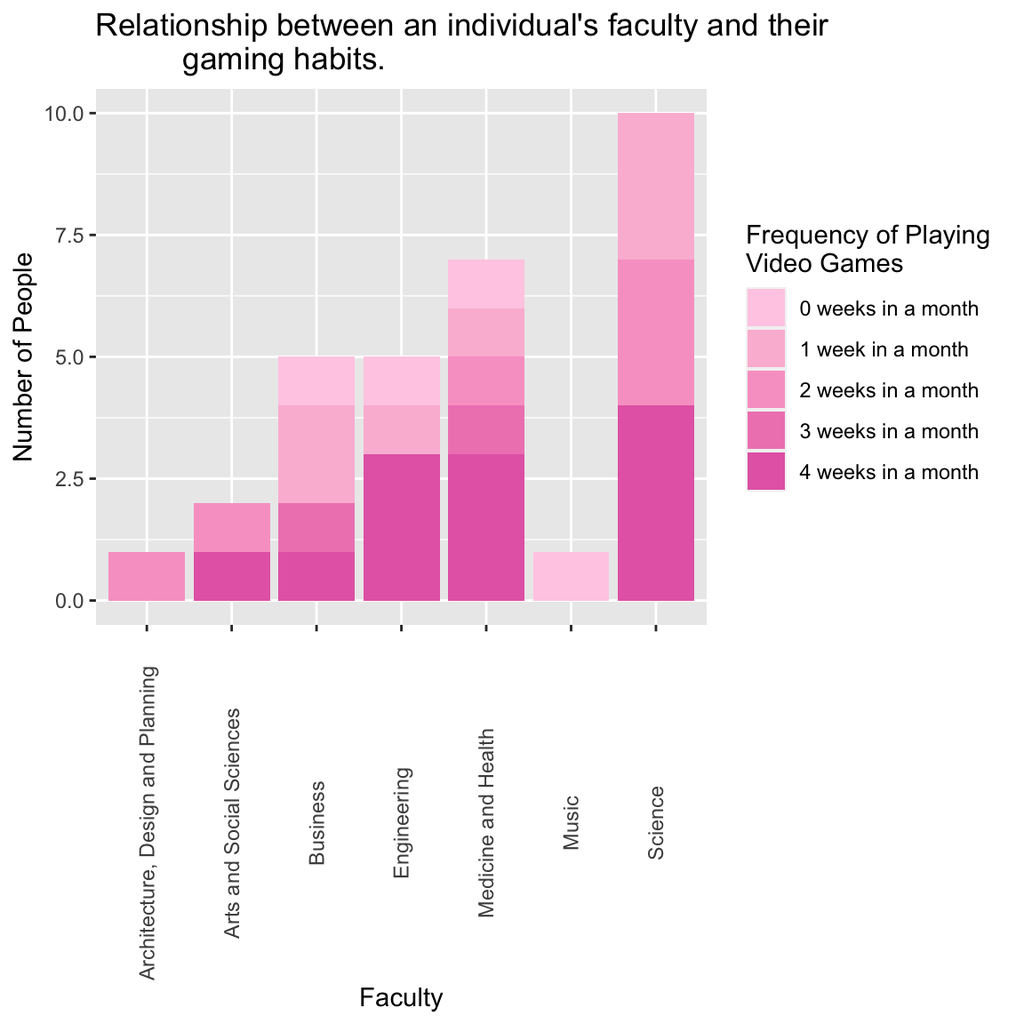

```r
ggplot(survey, aes(x = Faculty)) +
  geom_bar(aes(fill = Weeks_Last_Month_Played_Videogames)) +
  ggtitle("Relationship between an individual's faculty and their
          gaming habits.") +
  labs(x = "Faculty", y = "Number of People") +
  labs(fill = "Frequency of Playing \nVideo Games") +
  scale_fill_manual(values = c("0 weeks in a month" = "#FFCEE6",
                               "1 week in a month" = "#FCBCD7",
                               "2 weeks in a month" = "#F9A3CB",
                               "3 weeks in a month" = "#EF87BE",
                               "4 weeks in a month" = "#E56AB3")) +
  theme(axis.text.x=element_text(angle=90,margin = margin(0.5, unit = "cm"),vjust =0.5))
```

**Figure 3.** Bar plot showing the relationship between an individual’s faculty and frequency of playing video games in a month.

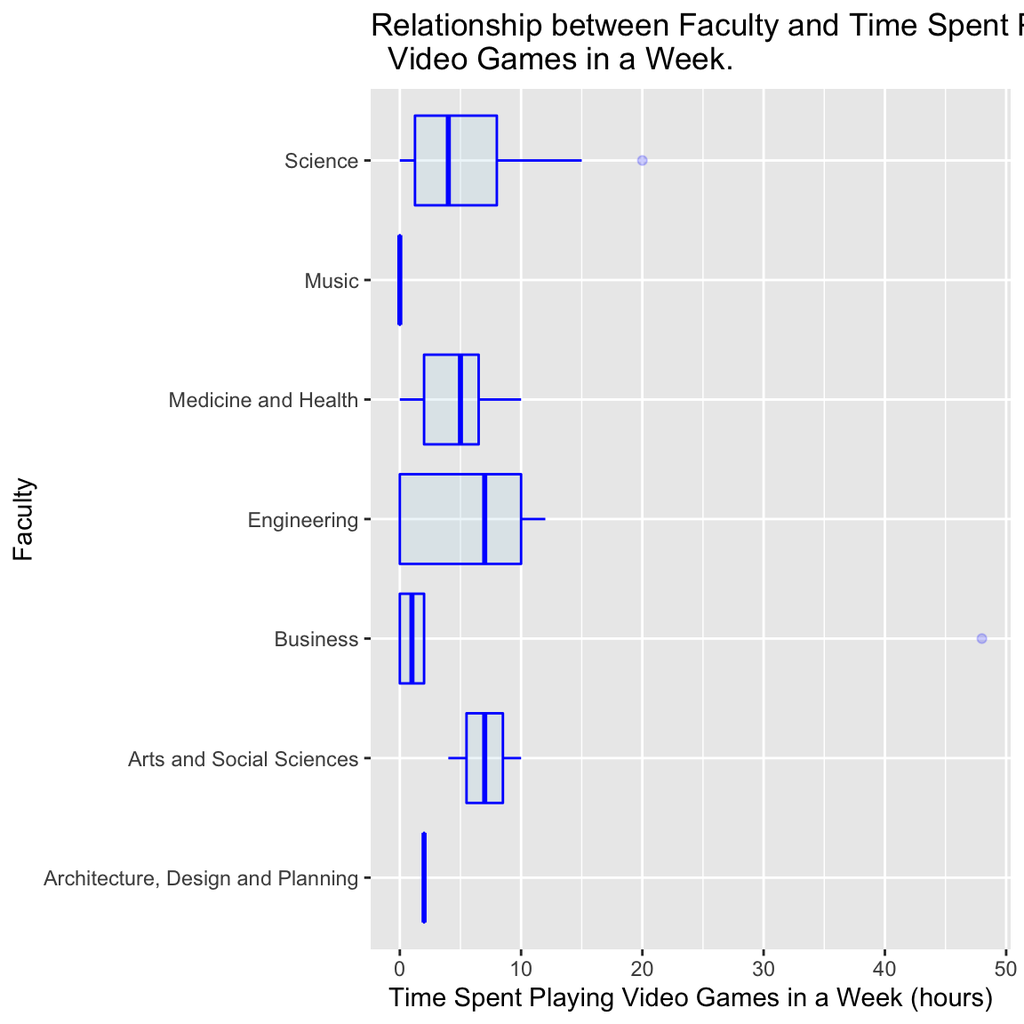

```r
# Filter data:

# Engineering
facultyE = survey$Hours_A_Week_Playing_Video_Game[survey$Faculty == "Engineering"]

# Medicine and Health
facultyM <- survey$Hours_A_Week_Playing_Video_Game[survey$Faculty == "Medicine and Health"]

# Science
facultyA <- survey$Hours_A_Week_Playing_Video_Game[survey$Faculty == "Science"]

ggplot(survey, aes(x = Hours_A_Week_Playing_Video_Game, y =Faculty,)) +
  geom_boxplot(color="blue", fill="light blue", alpha=0.2) +
  ggtitle("Relationship between Faculty and Time Spent Playing
  Video Games in a Week.") +
  xlab("Time Spent Playing Video Games in a Week (hours)")
```

**Figure 4.** Comparative box plot showing the relationship between an individual’s faculty and time spent playing video games in a week in hours.

### 2.2.3 3. How does the amount of time you spend on campus influence the number of hours you sleep at night?

- We can generate a scatter plot for the two quantitative variables:

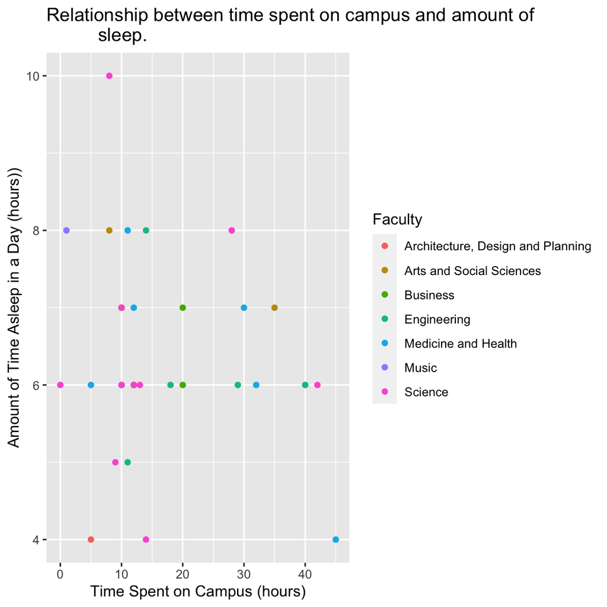

```r
ggplot(survey, aes(x = Hours_On_Campus, y = Hours_Of_Sleep)) +
  geom_point(aes(colour = Faculty)) +
  ggtitle("Relationship between time spent on campus and amount of
          sleep.") +
  xlab("Time Spent on Campus (hours)") +
  ylab("Amount of Time Asleep in a Day (hours))")
```

- We can also calculate the correlation:

```r
cor(survey$Hours_On_Campus, survey$Hours_Of_Sleep)
```

```
[1] -0.1774387
```

- There seems to be a very weak negative correlation between the two variables. We can attempt to fit a linear model to the data, and produce a residual graph:

[figure not shown]

```r
fitt = lm(survey$Hours_Of_Sleep~ survey$Hours_On_Campus, data = survey)
ggplot(fit, aes(x = .fitted, y = .resid)) +
  geom_point() +
  geom_hline(yintercept = 0, linetype = "dashed", colour = "red") +
  ggtitle("Residual vs Fitted.")
```

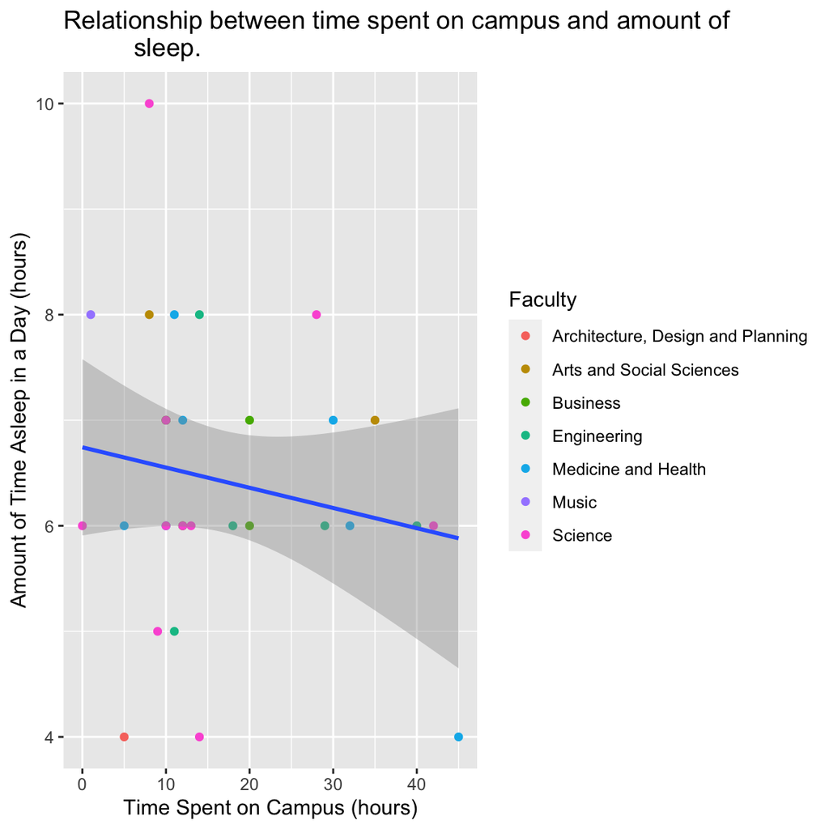

```r
ggplot(survey, aes(x = Hours_On_Campus , y = Hours_Of_Sleep))+
  geom_point(aes(colour = Faculty)) +
  geom_smooth(method = "lm") +
  ggtitle("Relationship between time spent on campus and amount of
          sleep.") +
  xlab("Time Spent on Campus (hours)") +
  ylab("Amount of Time Asleep in a Day (hours)")
```

**Figure 5.** Scatter plot demonstrating relationship between on campus hours and hours of sleep in a day The blue line represents the line of best fit for the data.

- Figure 5 demonstrates an attempt at linear regression.
- It seems that the linear model is not a good fit as the residual plot shows a possible pattern and the correlation coefficient of the two variables is weak.

### 2.2.4 4. How does your faculty influence the genre of video games you play most?

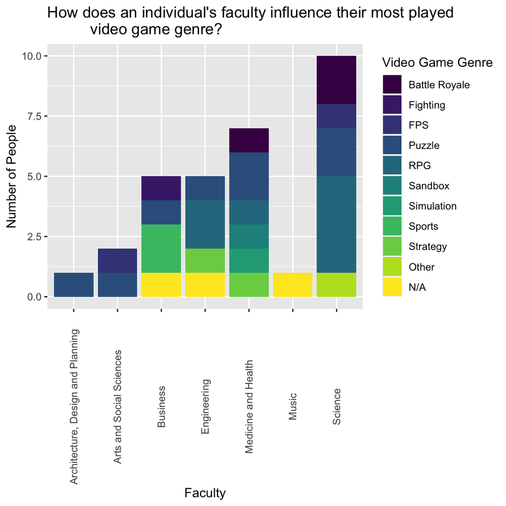

```r
order_Genre = ordered(survey$Favourite_Game_Genre,
                           levels=c("Battle Royale", "Fighting", "FPS", "Puzzle", "RPG",
                                    "Sandbox", "Simulation", "Sports", "Strategy",
                                    "Other", "N/A"))
ggplot(survey, aes(x = Faculty)) +
  geom_bar(aes(fill = order_Genre)) +
  ggtitle("How does an individual's faculty influence their most played
          video game genre?") +
  labs(x = "Faculty", y = "Number of People") +
  labs(fill = "Video Game Genre") +
  theme(axis.text.x=element_text(angle=90,margin = margin(0.5, unit = "cm"),vjust =0.5))
```

**Figure 6.** Bar plot demonstrating the relationship between an individual’s faculty and their most frequently played video game genre.

## 2.4 References

- Magali, M. (2008). Students and Video Game Players. *SSRN 1302868.*
- Muhamad, M., Muhammad, M. Z., Yunoh, M. N. M., Musa, Z. K. C., Hassan, A. A. M., Abdullah, A. R., & Mohd, F. (2023). The Causation of Online Game Addiction Among University Student. In *International Conference on Business and Technology* (pp. 1025-1033). Springer, Cham.

## 2.5 Acknowledgments

- Video called 08/09/2022 for 1 hour
  - Decided to investigate gaming habits, an individual’s faculty, and sleep
  - Delegated roles for the project:
    - **Nicole:** Executive Summary
    - **Phuong:** Initial Data Analysis
    - **Nabila:** Research Theme
    - **Antonia:** Articles and References
    - **Coco:** Video
- Video called 21/09/2022 for 2 hours
  - Compiled all our work
  - Updated the Rmd file to include ES, IDA, coding, and articles